**KNN**

According to this algorithm, which is used in classification, feature extraction during classification is used to look at the closeness of the new individual to be categorized to k of the previous individuals. For example, you want to classify a new element for k = 3. in this case the nearest 3 of the old classified elements are taken. If these elements are included in the class, the new element is also included in that class. The euclide distance can be used in the distance calculation.

# Project - Classify Type of Patient from the biomechanical features of orthopedic patients. (Total 30 marks)

# Install the necessary libraries (1 mark)

```python
import pandas as pd
import numpy as np
import seaborn as sns
from scipy.stats import zscore
from sklearn.model_selection import train_test_split
from sklearn.neighbors import KNeighborsClassifier
from sklearn.model_selection import cross_val_score
import scipy.stats as stats
import matplotlib.pyplot as plt
from scipy.stats import zscore
from sklearn import metrics
from sklearn.preprocessing import MinMaxScaler
from sklearn import preprocessing
from sklearn.model_selection import cross_val_score
from sklearn.preprocessing import LabelEncoder
```

# import data 2C_weka.csv for 2 Class Classifcation. (1 mark)

```python
data_2classdata=pd.read_csv("2Classdata.csv")
data_2classdata.head()
```

|  | pelvic_incidence | pelvic_tilt numeric | lumbar_lordosis_angle | sacral_slope | pelvic_radius | degree_spondylolisthesis | class |
| --- | --- | --- | --- | --- | --- | --- | --- |
| 0 | 63.027818 | 22.552586 | 39.609117 | 40.475232 | 98.672917 | -0.254400 | Abnormal |
| 1 | 39.056951 | 10.060991 | 25.015378 | 28.995960 | 114.405425 | 4.564259 | Abnormal |
| 2 | 68.832021 | 22.218482 | 50.092194 | 46.613539 | 105.985135 | -3.530317 | Abnormal |
| 3 | 69.297008 | 24.652878 | 44.311238 | 44.644130 | 101.868495 | 11.211523 | Abnormal |
| 4 | 49.712859 | 9.652075 | 28.317406 | 40.060784 | 108.168725 | 7.918501 | Abnormal |

# Explore the data set.Get necessary information about the data. (4 marks)

Look at the head and tail of dataset. Find the missing value. Look at the unique values of class values. Look at the distribution of class values and other attributes. Get the datatype information about the dataset Plot the distribution of different classes for pelvic_radius and sacral_slope for visualization.

```python
#getting the shape of our dataset
data_2classdata.shape
```

```
(310, 7)
```

```python
#checking 5 point summary of numerical attributes
data_2classdata.describe().T
```

|  | count | mean | std | min | 25% | 50% | 75% | max |
| --- | --- | --- | --- | --- | --- | --- | --- | --- |
| pelvic_incidence | 310.0 | 60.496653 | 17.236520 | 26.147921 | 46.430294 | 58.691038 | 72.877696 | 129.834041 |
| pelvic_tilt numeric | 310.0 | 17.542822 | 10.008330 | -6.554948 | 10.667069 | 16.357689 | 22.120395 | 49.431864 |
| lumbar_lordosis_angle | 310.0 | 51.930930 | 18.554064 | 14.000000 | 37.000000 | 49.562398 | 63.000000 | 125.742385 |
| sacral_slope | 310.0 | 42.953831 | 13.423102 | 13.366931 | 33.347122 | 42.404912 | 52.695888 | 121.429566 |
| pelvic_radius | 310.0 | 117.920655 | 13.317377 | 70.082575 | 110.709196 | 118.268178 | 125.467674 | 163.071041 |
| degree_spondylolisthesis | 310.0 | 26.296694 | 37.559027 | -11.058179 | 1.603727 | 11.767934 | 41.287352 | 418.543082 |

```python
#checking for types of each columns in the dataset
data_2classdata.dtypes
```

```
pelvic_incidence            float64
pelvic_tilt numeric         float64
lumbar_lordosis_angle       float64
sacral_slope                float64
pelvic_radius               float64
degree_spondylolisthesis    float64
class                        object
dtype: object
```

```python
#checking for any missing values
data_2classdata.isna().sum()
```

```
pelvic_incidence            0
pelvic_tilt numeric         0
lumbar_lordosis_angle       0
sacral_slope                0
pelvic_radius               0
degree_spondylolisthesis    0
class                       0
dtype: int64
```

```python
data_2classdata.groupby(["class"]).count()
# Class distribution among Abnormal and Normal patient is almost 2:1. The model will better predict Abnormal and Normal
```

| class | pelvic_incidence | pelvic_tilt numeric | lumbar_lordosis_angle | sacral_slope | pelvic_radius | degree_spondylolisthesis |
| --- | --- | --- | --- | --- | --- | --- |
| Abnormal | 210 | 210 | 210 | 210 | 210 | 210 |
| Normal | 100 | 100 | 100 | 100 | 100 | 100 |

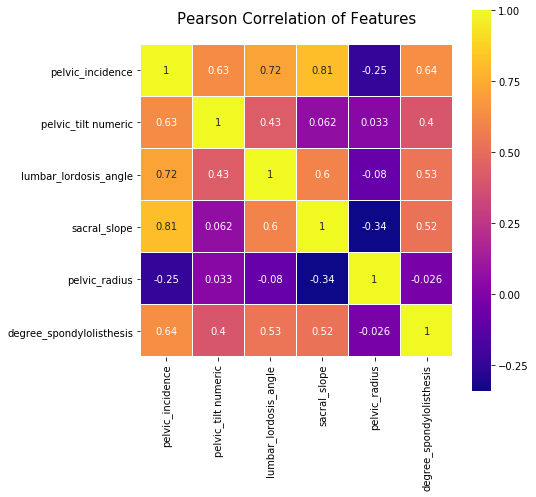

```python
colormap = plt.cm.plasma
plt.figure(figsize=(7,7))
plt.title('Pearson Correlation of Features', y=1.05, size=15)
sns.heatmap(data_2classdata.corr(),linewidths=0.1,vmax=1.0, square=True, cmap=colormap,
            linecolor='white', annot=True)
```

###### Checking measure of skewness along with plotting on respective column of a dataset as part of EDA.

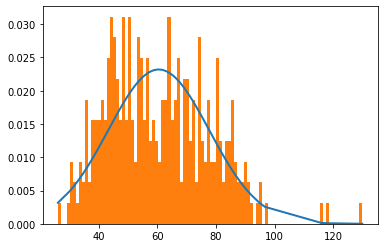

```
Skew = 0.5204398948625644
the distribution is moderately skewed as skewness value lies between 0.5 and 1
```

```python
#convert othopedic class2 DataFrame object to numpy array and sort
numpydf = np.asarray(data_2classdata['pelvic_incidence'])
numpydf = sorted(numpydf)

#use the scipy stats module to fit a normal distirbution with same mean and standard deviation
fit = stats.norm.pdf(numpydf, np.mean(numpydf), np.std(numpydf))

#plot both series on the histogram
plt.plot(numpydf ,fit,'-',linewidth = 2)
plt.hist(numpydf, normed=True, bins = 100)
plt.show()

print('Skew =', data_2classdata['pelvic_incidence'].skew())
print("the distribution is moderately skewed as skewness value lies between 0.5 and 1")
```

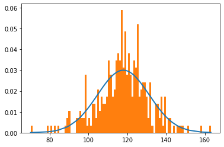

[output not shown]

```python
#convert othopedic class2 DataFrame object to numpy array and sort
numpydf = np.asarray(data_2classdata['pelvic_radius'])
numpydf = sorted(numpydf)

#use the scipy stats module to fit a normal distirbution with same mean and standard deviation
fit = stats.norm.pdf(numpydf, np.mean(numpydf), np.std(numpydf))

#plot both series on the histogram
plt.plot(numpydf ,fit,'-',linewidth = 2)
plt.hist(numpydf, normed=True, bins = 100)
plt.show()

print('Skew =', data_2classdata['pelvic_radius'].skew())
print("the distribution is moderately skewed as skewness value lies between -1 and -0.5")
```

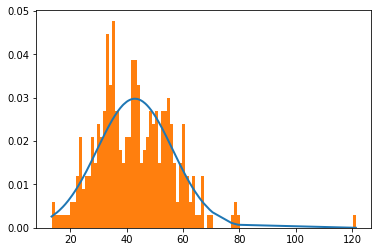

```
Skew = 0.7925766941630665
the distribution is moderately skewed as skewness value lies between 0.5 and 1
```

```python
#convert othopedic class2 DataFrame object to numpy array and sort
numpydf = np.asarray(data_2classdata['sacral_slope'])
numpydf = sorted(numpydf)

#use the scipy stats module to fit a normal distirbution with same mean and standard deviation
fit = stats.norm.pdf(numpydf, np.mean(numpydf), np.std(numpydf))

#plot both series on the histogram
plt.plot(numpydf ,fit,'-',linewidth = 2)
plt.hist(numpydf, normed=True, bins = 100)
plt.show()

print('Skew =', data_2classdata['sacral_slope'].skew())
print("the distribution is moderately skewed as skewness value lies between 0.5 and 1")
```

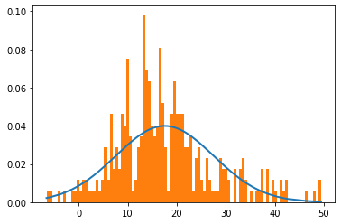

```
Skew = 0.6765533590425815
the distribution is moderately skewed as skewness value lies between 0.5 and 1
```

```python
#convert othopedic class2 DataFrame object to numpy array and sort
numpydf = np.asarray(data_2classdata['pelvic_tilt numeric'])
numpydf = sorted(numpydf)

#use the scipy stats module to fit a normal distirbution with same mean and standard deviation
fit = stats.norm.pdf(numpydf, np.mean(numpydf), np.std(numpydf))

#plot both series on the histogram
plt.plot(numpydf ,fit,'-',linewidth = 2)
plt.hist(numpydf, normed=True, bins = 100)
plt.show()

print('Skew =', data_2classdata['pelvic_tilt numeric'].skew())
print("the distribution is moderately skewed as skewness value lies between 0.5 and 1")
```

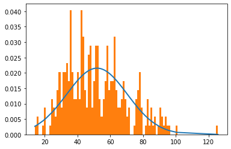

```
Skew = 0.5994514775939379
the distribution is moderately skewed as skewness value lies between 0.5 and 1
```

```python
#convert othopedic class2 DataFrame object to numpy array and sort
numpydf = np.asarray(data_2classdata['lumbar_lordosis_angle'])
numpydf = sorted(numpydf)

#use the scipy stats module to fit a normal distirbution with same mean and standard deviation
fit = stats.norm.pdf(numpydf, np.mean(numpydf), np.std(numpydf))

#plot both series on the histogram
plt.plot(numpydf ,fit,'-',linewidth = 2)
plt.hist(numpydf, normed=True, bins = 100)
plt.show()

print('Skew =', data_2classdata['lumbar_lordosis_angle'].skew())
print("the distribution is moderately skewed as skewness value lies between 0.5 and 1")
```

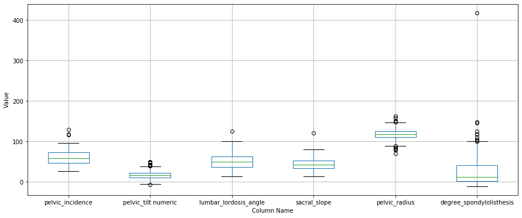

```python
#checking presence of outlier on the dataframe
# removing class column just to check

temp_df=data_2classdata.drop('class', axis=1)
plt.figure(figsize = (15,6))
plt.xlabel('Column Name')
plt.ylabel('Value')
temp_df.boxplot()
```

##### the above plot shows that there are number of outliers present on every column of a dataset. So next we need to find the number of outliers and where are they present

```python
#function to get the outliers on the specific columns
def get_outliers(datafr):
    out=[]
    Q1 = datafr.quantile(0.25)
    Q3 = datafr.quantile(0.75)
    IQR = Q3 - Q1
    lower_bound=Q1 - 1.5 * IQR
    upper_bound=Q3 + 1.5 * IQR
    for item in datafr:
        if((item<lower_bound) | (item>upper_bound)):
            out.append(item)
    return out
```

```python
#calculating interquartile range for finding outliers values
Q1 = data_2classdata.quantile(0.25)
Q3 = data_2classdata.quantile(0.75)
IQR = Q3 - Q1
print(IQR)
```

```
pelvic_incidence            26.447401
pelvic_tilt numeric         11.453326
lumbar_lordosis_angle       26.000000
sacral_slope                19.348766
pelvic_radius               14.758478
degree_spondylolisthesis    39.683625
dtype: float64
```

###### Finding Outliers for pelvice_incidence column

```python
#assigning the pelvic_incidence column value to a new dataframe for finding outlier
df_pelvice_incidence =data_2classdata['pelvic_incidence']
#calling the function to get outliers
pelvice_incidenceoutliers=get_outliers(df_pelvice_incidence)
print("Total Number of outliers present in the pelvice_incidence column of the dataframe =", len(pelvice_incidenceoutliers))
if len(pelvice_incidenceoutliers)<=0:
  print("The outliers values that resides in the BMI column are 0")
else:
    print("The outliers values that resides in the BMI column are", pelvice_incidenceoutliers)
```

[output not shown]

###### Finding Outliers for pelvic_tilt numeric column

```python
#assigning the pelivc_tilt numeric column value to a new dataframe for finding outlier
df_pelvice_tilt =data_2classdata['pelvic_tilt numeric']
#calling the function to get outliers
pelvic_tiltoutliers=get_outliers(df_pelvice_tilt)
print("Total Number of outliers present in the pelvice_tilt numeric column of the dataframe =", len(pelvic_tiltoutliers))
if len(pelvic_tiltoutliers)<=0:
  print("The outliers values that resides in the Pelvic_Tilt column are 0")
else:
    print("The outliers values that resides in the Pelvic_Tilt column are", pelvic_tiltoutliers)
```

```
Total Number of outliers present in the pelvice_tilt numeric column of the dataframe = 13
The outliers values that resides in the Pelvic_Tilt column are [41.55733141, 41.28630543, 39.82272448, 42.39620445, -6.554948347000001, 48.06953097, 39.84466878, 48.90365265, 42.68919513, 49.4318636, 40.30376567, 41.93368293, 46.55005318]
```

###### Finding Outliers for lumbar_lordosis_angle column

```python
#assigning the pelivc_tilt numeric column value to a new dataframe for finding outlier
df_lumbar_lordosis_angle =data_2classdata['lumbar_lordosis_angle']
#calling the function to get outliers
lumbar_lordosis_angleoutliers=get_outliers(df_lumbar_lordosis_angle)
print("Total Number of outliers present in the lumber_lordosis numeric column of the dataframe =", len(lumbar_lordosis_angleoutliers))
if len(lumbar_lordosis_angleoutliers)<=0:
  print("The outliers values that resides in the lumbar_lordosis_angle column are 0")
else:
    print("The outliers values that resides in the lumbar_lordosis_angle column are", lumbar_lordosis_angleoutliers)
```

```
Total Number of outliers present in the lumber_lordosis numeric column of the dataframe = 1
The outliers values that resides in the lumbar_lordosis_angle column are [125.7423855]
```

###### Finding Outliers for sacral_slope column

```python
#assigning the sacral_slope numeric column value to a new dataframe for finding outlier
df_sacral_slope =data_2classdata['sacral_slope']
#calling the function to get outliers
sacral_slope_outliers=get_outliers(df_sacral_slope)
print("Total Number of outliers present in the sacral_slope numeric column of the dataframe =", len(sacral_slope_outliers))
if len(lumbar_lordosis_angleoutliers)<=0:
  print("The outliers values that resides in the sacral_slope column are 0")
else:
    print("The outliers values that resides in the sacral_slope column are", sacral_slope_outliers)
```

```
Total Number of outliers present in the sacral_slope numeric column of the dataframe = 1
The outliers values that resides in the sacral_slope column are [121.42956559999999]
```

###### Finding Outliers for pelvic_radius column

```python
#assigning the pelvic_radius numeric column value to a new dataframe for finding outlier
df_pelvic_radius =data_2classdata['pelvic_radius']
#calling the function to get outliers
pelvic_radius_outliers=get_outliers(df_pelvic_radius)
print("Total Number of outliers present in the pelvic_radius numeric column of the dataframe =", len(pelvic_radius_outliers))
if len(pelvic_radius_outliers)<=0:
  print("The outliers values that resides in the pelvic_radius column are 0")
else:
    print("The outliers values that resides in the pelvic_radius column are", pelvic_radius_outliers)
```

```
Total Number of outliers present in the pelvic_radius numeric column of the dataframe = 11
The outliers values that resides in the pelvic_radius column are [84.24141517, 148.5255624, 151.8398566, 163.0710405, 82.45603817, 81.0245406, 70.08257486, 78.99945411, 157.84879899999999, 88.43424213, 147.8946372]
```

###### Finding Outliers for degree_spondylolisthesis column

```python
#assigning the degree_spondylolisthesis numeric column value to a new dataframe for finding outlier
df_degree_spondylolisthesis =data_2classdata['degree_spondylolisthesis']
#calling the function to get outliers
degree_spondylolisthesis_outliers=get_outliers(df_degree_spondylolisthesis)
print("Total Number of outliers present in the degree_spondylolisthesis numeric column of the dataframe =", len(degree_spondylolisthesis_outliers))
if len(pelvic_radius_outliers)<=0:
  print("The outliers values that resides in the degree_spondylolisthesis column are 0")
else:
    print("The outliers values that resides in the degree_spondylolisthesis column are", degree_spondylolisthesis_outliers)
```

```
Total Number of outliers present in the degree_spondylolisthesis numeric column of the dataframe = 10
The outliers values that resides in the degree_spondylolisthesis column are [101.71909190000001, 145.37814319999998, 110.8607824, 148.75371090000002, 418.54308210000005, 118.35337009999999, 104.85924740000002, 124.9844057, 117.31468290000001, 101.2187828]
```

###### Pair plot for the othopedic class2 dataset

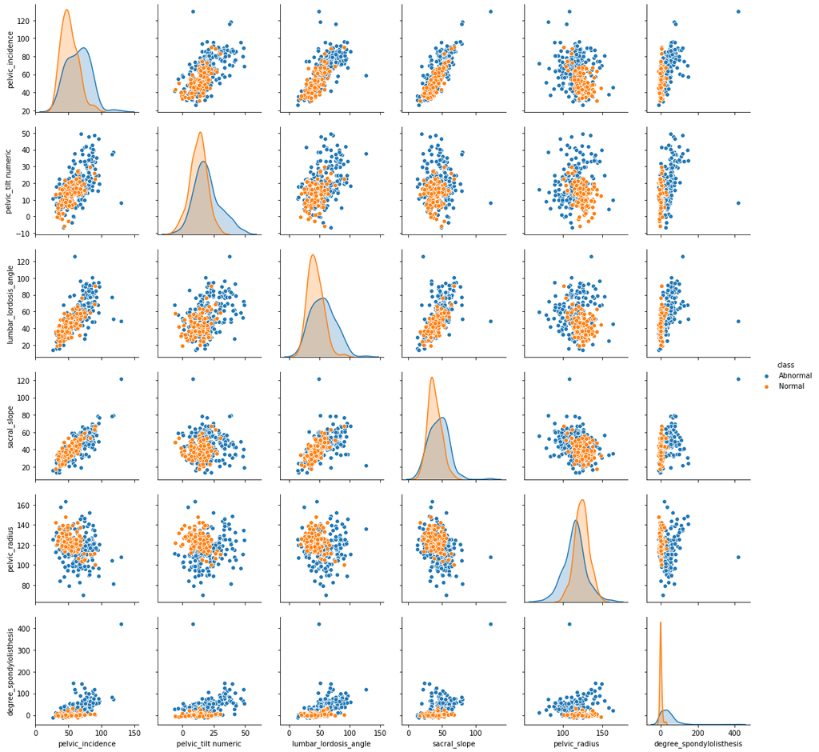

```python
sns.pairplot(data_2classdata, hue='class')
```

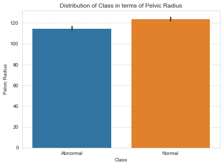

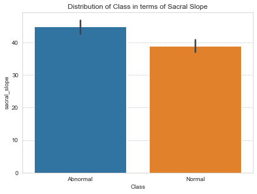

```python
sns.set_style("whitegrid", {'grid.linestyle': '--'})
plt.figure(figsize = (7,5))
sns.barplot(x = "class", y = "pelvic_radius", data = data_2classdata)
plt.xlabel("Class")
plt.ylabel("Pelvic Radius")
plt.title("Distribution of Class in terms of Pelvic Radius")

sns.set_style("whitegrid", {'grid.linestyle': '--'})
plt.figure(figsize = (7,5))
sns.barplot(x = "class", y = "sacral_slope", data = data_2classdata)
plt.xlabel("Class")
plt.ylabel("sacral_slope")
plt.title("Distribution of Class in terms of Sacral Slope")
```

# Encode the Class variable to integer. (2 marks)

```python
data_2classdata["class"] = [0 if each == "Abnormal" else 1 for each in data_2classdata["class"]]
```

```python
data_2classdata['class'].value_counts()
```

```
0    210
1    100
Name: class, dtype: int64
```

```python
data_2classdata.head()
```

|  | pelvic_incidence | pelvic_tilt numeric | lumbar_lordosis_angle | sacral_slope | pelvic_radius | degree_spondylolisthesis | class |
| --- | --- | --- | --- | --- | --- | --- | --- |
| 0 | 63.027818 | 22.552586 | 39.609117 | 40.475232 | 98.672917 | -0.254400 | 0 |
| 1 | 39.056951 | 10.060991 | 25.015378 | 28.995960 | 114.405425 | 4.564259 | 0 |
| 2 | 68.832021 | 22.218482 | 50.092194 | 46.613539 | 105.985135 | -3.530317 | 0 |
| 3 | 69.297008 | 24.652878 | 44.311238 | 44.644130 | 101.868495 | 11.211523 | 0 |
| 4 | 49.712859 | 9.652075 | 28.317406 | 40.060784 | 108.168725 | 7.918501 | 0 |

# Create the X(Feature-set) and Y(Target-set) sets for your Data. (2 marks)

```python
# Create a separate dataframe consisting only of the features i.e independent attributes
X = data_2classdata.drop(labels= "class" , axis = 1)
```

```python
X.head()
```

|  | pelvic_incidence | pelvic_tilt numeric | lumbar_lordosis_angle | sacral_slope | pelvic_radius | degree_spondylolisthesis |
| --- | --- | --- | --- | --- | --- | --- |
| 0 | 63.027818 | 22.552586 | 39.609117 | 40.475232 | 98.672917 | -0.254400 |
| 1 | 39.056951 | 10.060991 | 25.015378 | 28.995960 | 114.405425 | 4.564259 |
| 2 | 68.832021 | 22.218482 | 50.092194 | 46.613539 | 105.985135 | -3.530317 |
| 3 | 69.297008 | 24.652878 | 44.311238 | 44.644130 | 101.868495 | 11.211523 |
| 4 | 49.712859 | 9.652075 | 28.317406 | 40.060784 | 108.168725 | 7.918501 |

```python
y=data_2classdata[['class']]
y.head()
```

|  | class |
| --- | --- |
| 0 | 0 |
| 1 | 0 |
| 2 | 0 |
| 3 | 0 |
| 4 | 0 |

# Normalize your Data (X) to get values between 0 to 1. (2 marks)

```python
#normalising the value. Before applying the algorithm, I want to normalize X values. Normalization means scaling all values between 0 and 1. This is important not to ignore small values
#however, I can also use other normalisation technique as Zscore  etc.
mm_scaler = preprocessing.MinMaxScaler()
X = mm_scaler.fit_transform(X)
X
```

```
array([[0.35568788, 0.51989984, 0.22917997, 0.2508573 , 0.30746116,
        0.02514839],
       [0.12450104, 0.2967831 , 0.09857833, 0.14462935, 0.47664891,
        0.03636497],
       [0.41166648, 0.51393229, 0.32299466, 0.30766054, 0.38609692,
        0.0175229 ],
       ...,
       [0.34043781, 0.52244298, 0.28789745, 0.23490726, 0.59779618,
        0.01943732],
       [0.18425678, 0.27235174, 0.24684569, 0.21462279, 0.52117504,
        0.02624045],
       [0.07420202, 0.20770855, 0.20261992, 0.14251659, 0.57924032,
        0.02527676]])
```

```python
#from sklearn.preprocessing import LabelEncoder
#class_label_encoder = LabelEncoder()
```

```python
#y['class'] = class_label_encoder.fit_transform(y['class'])
```

# Split the dat as train and test with a ratio of 70:30. (2 marks)

```python
test_size=0.30
seed=7
X_train, X_test, y_train, y_test=train_test_split(X, y, test_size=test_size, random_state=seed)
```

```python
X_train.shape
```

```
(217, 6)
```

```python
X_test.shape
```

```
(93, 6)
```

```python
KNNH=KNeighborsClassifier(n_neighbors=5)
```

```python
y_train.shape
```

```
(217, 1)
```

# Build the KNN model using Train Dataset and predict the class on test dataset. (2 marks)

```python
KNNH.fit(X_train, y_train)
```

```
KNeighborsClassifier(algorithm='auto', leaf_size=30, metric='minkowski',
                     metric_params=None, n_jobs=None, n_neighbors=5, p=2,
                     weights='uniform')
```

```python
# For every test data point, predict it's label based on 5 nearest neighbours in this model. The majority class will
# be assigned to the test data point
predicted_labels = KNNH.predict(X_test)
```

```python
predicted_labels
```

```
array([1, 0, 0, 0, 0, 1, 0, 0, 1, 0, 0, 0, 0, 1, 0, 0, 0, 1, 1, 0, 0, 0,
       0, 0, 0, 1, 1, 0, 0, 0, 1, 0, 0, 0, 0, 0, 0, 0, 0, 0, 0, 1, 1, 0,
       0, 0, 0, 1, 0, 1, 0, 1, 0, 0, 0, 0, 0, 0, 0, 0, 0, 1, 0, 0, 0, 0,
       0, 0, 0, 0, 0, 1, 0, 0, 0, 0, 0, 1, 1, 0, 0, 0, 1, 0, 0, 1, 0, 1,
       1, 0, 0, 0, 0], dtype=int64)
```

# Calculate the performance score of of your classification on test dataset. (2 marks)

Hint- You can use knn.score( ) function.

```python
## Train Accuracy
print("Score for training data is =", KNNH.score(X_train, y_train))
```

```
Score for training data is = 0.8617511520737328
```

```python
## Test accuracy
print("Score for test data is =", KNNH.score(X_test, y_test))
```

```
Score for test data is = 0.7634408602150538
```

```python
## Test Confusion Matrix
knn_cm=metrics.confusion_matrix(y_test, KNNH.predict(X_test))
knn_cm
```

```
array([[54,  5],
       [17, 17]], dtype=int64)
```

# What is the best K value for your classifcation?

# Find at which k value you get the best score. (2 marks)

```python
from sklearn.model_selection import cross_val_score
```

```python
X_train.shape[0]
```

```
217
```

```python
maxK = int(np.sqrt(X_train.shape[0]))
maxK
```

```
14
```

```python
# creating odd list of K for KNN
myList = list(range(1,14))
```

```python
# subsetting just the odd ones
neighbors = list(filter(lambda x: x % 2 != 0, myList))
neighbors
```

```
[1, 3, 5, 7, 9, 11, 13]
```

```python
# empty list that will hold cv scores
cv_scores = []
```

```python
# perform 10-fold cross validation
for k in neighbors:
    knn = KNeighborsClassifier(n_neighbors=k)
    scores = cross_val_score(knn, X_train, y_train.values.ravel(), cv=10, scoring='accuracy') #used ravel() as it was giving warnings
    cv_scores.append(scores.mean())
```

```python
# changing to misclassification error
misError = [1 - x for x in cv_scores]
misError
```

```
[0.19009975531714662,
 0.21282702804441933,
 0.22626576322228498,
 0.22087332956898176,
 0.20267268962921137,
 0.1985601355166573,
 0.18860342555994725]
```

```python
optimal_k = neighbors[misError.index(min(misError))]
optimal_k
```

```
13
```

```python
# determining best k
optimal_k = neighbors[misError.index(min(misError))]
print("The optimal number of neighbors is ", optimal_k)
```

```
The optimal number of neighbors is  13
```

```python
NNH = KNeighborsClassifier(n_neighbors=optimal_k)
NNH.fit(X_train, y_train)
print(NNH.score(X_train, y_train))
print(NNH.score(X_test, y_test))
```

```
0.8202764976958525
0.8172043010752689
```

```python
# Confusion matrix
knn_cm=metrics.confusion_matrix(y_test, NNH.predict(X_test))
knn_cm
```

```
array([[56,  3],
       [14, 20]], dtype=int64)
```

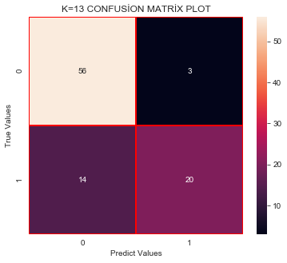

```python
#KNN CONFUSİON MATRİX PLOT
plt.figure(figsize=(6,5))
sns.heatmap(knn_cm, annot = True, linewidth = 0.5, linecolor="red", fmt = ".0f")
plt.xlabel("Predict Values")
plt.ylabel("True Values")
plt.title("K=13 CONFUSİON MATRİX PLOT")
plt.show()
```

```
k : 1 and Score: 0.7741935483870968
k : 2 and Score: 0.7634408602150538
k : 3 and Score: 0.7526881720430108
k : 4 and Score: 0.6989247311827957
k : 5 and Score: 0.7634408602150538
k : 6 and Score: 0.7311827956989247
k : 7 and Score: 0.8172043010752689
k : 8 and Score: 0.7634408602150538
k : 9 and Score: 0.8064516129032258
k : 10 and Score: 0.7956989247311828
k : 11 and Score: 0.8172043010752689
k : 12 and Score: 0.8172043010752689
k : 13 and Score: 0.8172043010752689
```

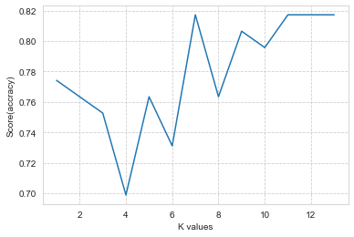

```
k : 13 and max Score: 0.8172043010752689
```

```python
#find avaible value of k
score_list=[]
k_value=[]
for i in myList:
    knn_available=KNeighborsClassifier(n_neighbors=i)
    knn_available.fit(X_train,y_train.values.ravel())

    score_list.append(knn_available.score(X_test,y_test))
    print("k : {} and Score: {}".format(i,knn_available.score(X_test,y_test)))
    k_value.append(i)
plt.plot(myList,score_list)
plt.xlabel("K values")
plt.ylabel("Score(accracy)")
plt.show()

#we will see when max accuracy with k value
print("k : {} and max Score: {}".format(i,np.max(score_list)))
```

# import data 3C_weka.csv for 3 Class Classifcation and repeat all the steps which are given above. (10 marks)

```python
data_3classdata=pd.read_csv("3Classdata.csv")
data_3classdata.head()
```

|  | pelvic_incidence | pelvic_tilt | lumbar_lordosis_angle | sacral_slope | pelvic_radius | degree_spondylolisthesis | class |
| --- | --- | --- | --- | --- | --- | --- | --- |
| 0 | 63.027818 | 22.552586 | 39.609117 | 40.475232 | 98.672917 | -0.254400 | Hernia |
| 1 | 39.056951 | 10.060991 | 25.015378 | 28.995960 | 114.405425 | 4.564259 | Hernia |
| 2 | 68.832021 | 22.218482 | 50.092194 | 46.613539 | 105.985135 | -3.530317 | Hernia |
| 3 | 69.297008 | 24.652878 | 44.311238 | 44.644130 | 101.868495 | 11.211523 | Hernia |
| 4 | 49.712859 | 9.652075 | 28.317406 | 40.060784 | 108.168725 | 7.918501 | Hernia |

```python
#fetching the shape of the dataset
data_3classdata.shape
```

```
(310, 7)
```

```python
#5 point Summary of the dataset
data_3classdata.describe().T
```

|  | count | mean | std | min | 25% | 50% | 75% | max |
| --- | --- | --- | --- | --- | --- | --- | --- | --- |
| pelvic_incidence | 310.0 | 60.496653 | 17.236520 | 26.147921 | 46.430294 | 58.691038 | 72.877696 | 129.834041 |
| pelvic_tilt | 310.0 | 17.542822 | 10.008330 | -6.554948 | 10.667069 | 16.357689 | 22.120395 | 49.431864 |
| lumbar_lordosis_angle | 310.0 | 51.930930 | 18.554064 | 14.000000 | 37.000000 | 49.562398 | 63.000000 | 125.742385 |
| sacral_slope | 310.0 | 42.953831 | 13.423102 | 13.366931 | 33.347122 | 42.404912 | 52.695888 | 121.429566 |
| pelvic_radius | 310.0 | 117.920655 | 13.317377 | 70.082575 | 110.709196 | 118.268178 | 125.467674 | 163.071041 |
| degree_spondylolisthesis | 310.0 | 26.296694 | 37.559027 | -11.058179 | 1.603727 | 11.767934 | 41.287352 | 418.543082 |

```python
# fetching the column types in the dataset
data_3classdata.dtypes
```

```
pelvic_incidence            float64
pelvic_tilt                 float64
lumbar_lordosis_angle       float64
sacral_slope                float64
pelvic_radius               float64
degree_spondylolisthesis    float64
class                        object
dtype: object
```

```python
#checking for any missing value
data_3classdata.isna().sum()
```

```
pelvic_incidence            0
pelvic_tilt                 0
lumbar_lordosis_angle       0
sacral_slope                0
pelvic_radius               0
degree_spondylolisthesis    0
class                       0
dtype: int64
```

```python
#Grouping the data of the class variable and checking the value exsiting for each column
data_3classdata.groupby(["class"]).count()
```

| class | pelvic_incidence | pelvic_tilt | lumbar_lordosis_angle | sacral_slope | pelvic_radius | degree_spondylolisthesis |
| --- | --- | --- | --- | --- | --- | --- |
| Hernia | 60 | 60 | 60 | 60 | 60 | 60 |
| Normal | 100 | 100 | 100 | 100 | 100 | 100 |
| Spondylolisthesis | 150 | 150 | 150 | 150 | 150 | 150 |

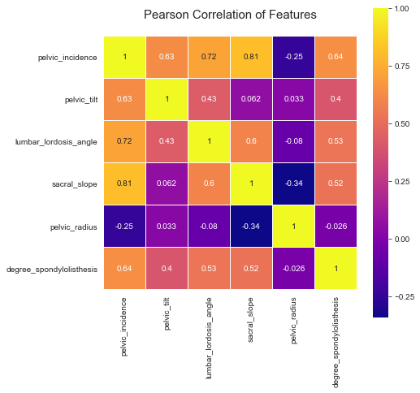

```python
colormap = plt.cm.plasma
plt.figure(figsize=(7,7))
plt.title('Pearson Correlation of Features', y=1.05, size=15)
sns.heatmap(data_3classdata.corr(),linewidths=0.1,vmax=1.0, square=True, cmap=colormap,
            linecolor='white', annot=True)
```

###### Checking measure of skewness along with plotting on respective column of a dataset as part of EDA

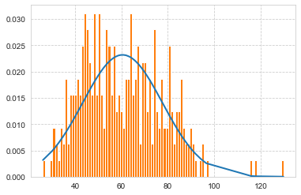

```
Skew = 0.5204398948625644
the distribution is moderately skewed as skewness value lies between 0.5 and 1
```

```python
#convert othopedic class3 DataFrame object to numpy array and sort
numpydf = np.asarray(data_3classdata['pelvic_incidence'])
numpydf = sorted(numpydf)

#use the scipy stats module to fit a normal distirbution with same mean and standard deviation
fit = stats.norm.pdf(numpydf, np.mean(numpydf), np.std(numpydf))

#plot both series on the histogram
plt.plot(numpydf ,fit,'-',linewidth = 2)
plt.hist(numpydf, normed=True, bins = 100)
plt.show()

print('Skew =', data_3classdata['pelvic_incidence'].skew())
print("the distribution is moderately skewed as skewness value lies between 0.5 and 1")
```

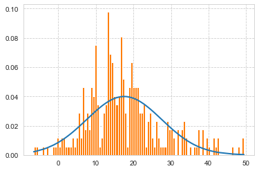

```
Skew = 0.6765533590425815
the distribution is moderately skewed as skewness value lies between 0.5 and 1
```

```python
#convert othopedic class3 DataFrame object to numpy array and sort
numpydf = np.asarray(data_3classdata['pelvic_tilt'])
numpydf = sorted(numpydf)

#use the scipy stats module to fit a normal distirbution with same mean and standard deviation
fit = stats.norm.pdf(numpydf, np.mean(numpydf), np.std(numpydf))

#plot both series on the histogram
plt.plot(numpydf ,fit,'-',linewidth = 2)
plt.hist(numpydf, normed=True, bins = 100)
plt.show()

print('Skew =', data_3classdata['pelvic_tilt'].skew())
print("the distribution is moderately skewed as skewness value lies between 0.5 and 1")
```

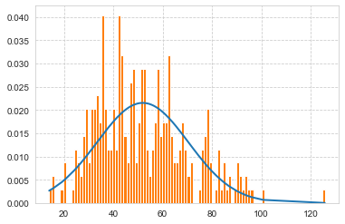

```
Skew = 0.5994514775939379
the distribution is moderately skewed to the right as skewness value lies between 0.5 and 1
```

```python
#convert othopedic class3 DataFrame object to numpy array and sort
numpydf = np.asarray(data_3classdata['lumbar_lordosis_angle'])
numpydf = sorted(numpydf)

#use the scipy stats module to fit a normal distirbution with same mean and standard deviation
fit = stats.norm.pdf(numpydf, np.mean(numpydf), np.std(numpydf))

#plot both series on the histogram
plt.plot(numpydf ,fit,'-',linewidth = 2)
plt.hist(numpydf, normed=True, bins = 100)
plt.show()

print('Skew =', data_3classdata['lumbar_lordosis_angle'].skew())
print("the distribution is moderately skewed to the right as skewness value lies between 0.5 and 1")
```

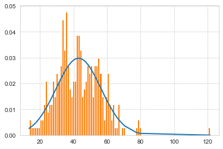

```
Skew = 0.7925766941630665
the distribution is moderately skewed to the right as skewness value lies between 0.5 and 1
```

```python
#convert othopedic class3 DataFrame object to numpy array and sort
numpydf = np.asarray(data_3classdata['sacral_slope'])
numpydf = sorted(numpydf)

#use the scipy stats module to fit a normal distirbution with same mean and standard deviation
fit = stats.norm.pdf(numpydf, np.mean(numpydf), np.std(numpydf))

#plot both series on the histogram
plt.plot(numpydf ,fit,'-',linewidth = 2)
plt.hist(numpydf, normed=True, bins = 100)
plt.show()

print('Skew =', data_3classdata['sacral_slope'].skew())
print("the distribution is moderately skewed to the right as skewness value lies between 0.5 and 1")
```

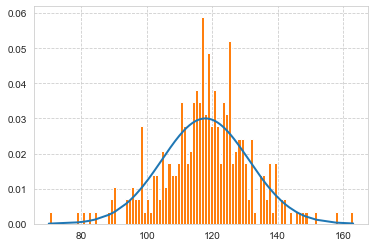

```
Skew = -0.17683486805355692
the distribution is approximately symmetric as the value lies between -0.5 and +0.5
```

```python
#convert othopedic class3 DataFrame object to numpy array and sort
numpydf = np.asarray(data_3classdata['pelvic_radius'])
numpydf = sorted(numpydf)

#use the scipy stats module to fit a normal distirbution with same mean and standard deviation
fit = stats.norm.pdf(numpydf, np.mean(numpydf), np.std(numpydf))

#plot both series on the histogram
plt.plot(numpydf ,fit,'-',linewidth = 2)
plt.hist(numpydf, normed=True, bins = 100)
plt.show()

print('Skew =', data_3classdata['pelvic_radius'].skew())
print("the distribution is approximately symmetric as the value lies between -0.5 and +0.5")
```

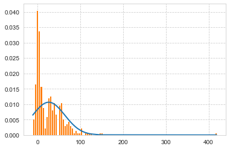

```
Skew = 4.317953644012236
the distribution is highly skewed to the right as skewness value is greater than 1
```

```python
#convert othopedic class3 DataFrame object to numpy array and sort
numpydf = np.asarray(data_3classdata['degree_spondylolisthesis'])
numpydf = sorted(numpydf)

#use the scipy stats module to fit a normal distirbution with same mean and standard deviation
fit = stats.norm.pdf(numpydf, np.mean(numpydf), np.std(numpydf))

#plot both series on the histogram
plt.plot(numpydf ,fit,'-',linewidth = 2)
plt.hist(numpydf, normed=True, bins = 100)
plt.show()

print('Skew =', data_3classdata['degree_spondylolisthesis'].skew())
print("the distribution is highly skewed to the right as skewness value is greater than 1")
```

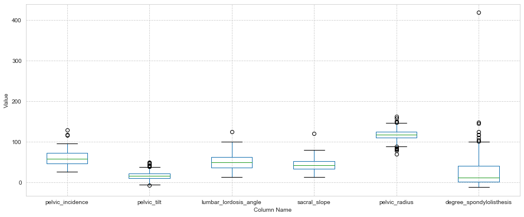

```python
#checking presence of outlier on the dataframe
# removing class column just to check

temp_df=data_3classdata.drop('class', axis=1)
plt.figure(figsize = (15,6))
plt.xlabel('Column Name')
plt.ylabel('Value')
temp_df.boxplot()
```

##### the above plot shows that there are number of outliers present on every column of a dataset. So next we need to find the number of outliers and where are they present

###### Finding Outliers for pelvice_incidence column

```python
#assigning the pelvic_incidence column value to a new dataframe for finding outlier
df_pelvice_incidence =data_3classdata['pelvic_incidence']
#calling the function to get outliers
pelvice_incidenceoutliers=get_outliers(df_pelvice_incidence)
print("Total Number of outliers present in the pelvice_incidence column of the dataframe =", len(pelvice_incidenceoutliers))
if len(pelvice_incidenceoutliers)<=0:
  print("The outliers values that resides in the pelvice_incidence column are 0")
else:
    print("The outliers values that resides in the pelvice_incidence column are", pelvice_incidenceoutliers)
```

```
Total Number of outliers present in the pelvice_incidence column of the dataframe = 3
The outliers values that resides in the pelvice_incidence column are [129.8340406, 118.1446548, 115.92326059999999]
```

```python
#assigning the pelvic_tilt column value to a new dataframe for finding outlier
df_pelvic_tilt =data_3classdata['pelvic_tilt']
#calling the function to get outliers
pelvic_tiltoutliers=get_outliers(df_pelvic_tilt)
print("Total Number of outliers present in the pelvic_tilt column of the dataframe =", len(pelvic_tiltoutliers))
if len(pelvice_incidenceoutliers)<=0:
  print("The outliers values that resides in the pelvic_tilt column are 0")
else:
    print("The outliers values that resides in the pelvic_tilt column are", pelvic_tiltoutliers)
```

```
Total Number of outliers present in the pelvic_tilt column of the dataframe = 13
The outliers values that resides in the pelvic_tilt column are [41.55733141, 41.28630543, 39.82272448, 42.39620445, -6.554948347000001, 48.06953097, 39.84466878, 48.90365265, 42.68919513, 49.4318636, 40.30376567, 41.93368293, 46.55005318]
```

```python
#assigning the lumbar_lordosis_angle column value to a new dataframe for finding outlier
df_lumbar_lordosis_angle =data_3classdata['lumbar_lordosis_angle']
#calling the function to get outliers
lumbar_lordosis_angleoutliers=get_outliers(df_lumbar_lordosis_angle)
print("Total Number of outliers present in the lumbar_lordosis_angle column of the dataframe =", len(lumbar_lordosis_angleoutliers))
if len(lumbar_lordosis_angleoutliers)<=0:
  print("The outliers values that resides in the lumbar_lordosis_angle column are 0")
else:
    print("The outliers values that resides in the lumbar_lordosis_angle column are", lumbar_lordosis_angleoutliers)
```

```
Total Number of outliers present in the lumbar_lordosis_angle column of the dataframe = 1
The outliers values that resides in the lumbar_lordosis_angle column are [125.7423855]
```

```python
#assigning the sacral_slope column value to a new dataframe for finding outlier
df_sacral_slope =data_3classdata['sacral_slope']
#calling the function to get outliers
sacral_slopeoutliers=get_outliers(df_sacral_slope)
print("Total Number of outliers present in the sacral_slope column of the dataframe =", len(sacral_slopeoutliers))
if len(sacral_slopeoutliers)<=0:
  print("The outliers values that resides in the sacral_slope column are 0")
else:
    print("The outliers values that resides in the sacral_slope column are", sacral_slopeoutliers)
```

```
Total Number of outliers present in the sacral_slope column of the dataframe = 1
The outliers values that resides in the sacral_slope column are [121.42956559999999]
```

```python
#assigning the pelvic_radius column value to a new dataframe for finding outlier
df_pelvice_incidence =data_3classdata['pelvic_radius']
#calling the function to get outliers
pelvic_radiusoutliers=get_outliers(df_pelvic_radius)
print("Total Number of outliers present in the pelvic_radius column of the dataframe =", len(pelvic_radiusoutliers))
if len(pelvic_radiusoutliers)<=0:
  print("The outliers values that resides in the pelvic_radius column are 0")
else:
    print("The outliers values that resides in the pelvic_radius column are", pelvic_radiusoutliers)
```

```
Total Number of outliers present in the pelvic_radius column of the dataframe = 11
The outliers values that resides in the pelvic_radius column are [84.24141517, 148.5255624, 151.8398566, 163.0710405, 82.45603817, 81.0245406, 70.08257486, 78.99945411, 157.84879899999999, 88.43424213, 147.8946372]
```

```python
#assigning the degree_spondylolisthesis column value to a new dataframe for finding outlier
df_degree_spondylolisthesis =data_3classdata['degree_spondylolisthesis']
#calling the function to get outliers
degree_spondylolisthesisoutliers=get_outliers(df_degree_spondylolisthesis)
print("Total Number of outliers present in the pelvice_incidence column of the dataframe =", len(degree_spondylolisthesisoutliers))
if len(degree_spondylolisthesisoutliers)<=0:
  print("The outliers values that resides in the degree_spondylolisthesis column are 0")
else:
    print("The outliers values that resides in the degree_spondylolisthesis column are", degree_spondylolisthesisoutliers)
```

[output not shown]

###### Pair plot for data3 class data

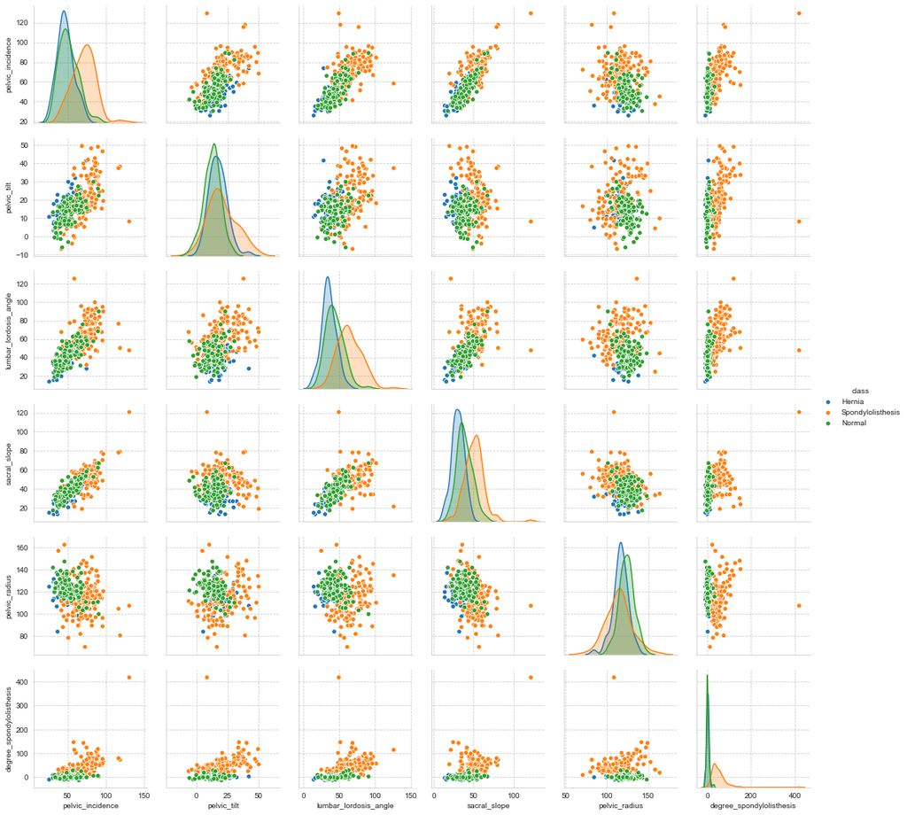

```python
sns.pairplot(data_3classdata, hue='class')
```

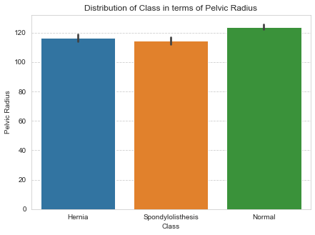

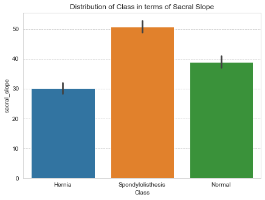

```python
sns.set_style("whitegrid", {'grid.linestyle': '--'})
plt.figure(figsize = (7,5))
sns.barplot(x = "class", y = "pelvic_radius", data = data_3classdata)
plt.xlabel("Class")
plt.ylabel("Pelvic Radius")
plt.title("Distribution of Class in terms of Pelvic Radius")

sns.set_style("whitegrid", {'grid.linestyle': '--'})
plt.figure(figsize = (7,5))
sns.barplot(x = "class", y = "sacral_slope", data = data_3classdata)
plt.xlabel("Class")
plt.ylabel("sacral_slope")
plt.title("Distribution of Class in terms of Sacral Slope")
```

```python
from sklearn.preprocessing import LabelEncoder
class_label_encoder = LabelEncoder()
data_3classdata['class'] = class_label_encoder.fit_transform(data_3classdata['class'])
```

```python
data_3classdata.groupby(["class"]).count()
```

| class | pelvic_incidence | pelvic_tilt | lumbar_lordosis_angle | sacral_slope | pelvic_radius | degree_spondylolisthesis |
| --- | --- | --- | --- | --- | --- | --- |
| 0 | 60 | 60 | 60 | 60 | 60 | 60 |
| 1 | 100 | 100 | 100 | 100 | 100 | 100 |
| 2 | 150 | 150 | 150 | 150 | 150 | 150 |

# Create the X(Feature-set) and Y(Target-set) sets for your Data.

```python
# Create a separate dataframe consisting only of the features i.e independent attributes
X_data3 = data_3classdata.drop(labels= "class" , axis = 1)
X_data3.head()
```

|  | pelvic_incidence | pelvic_tilt | lumbar_lordosis_angle | sacral_slope | pelvic_radius | degree_spondylolisthesis |
| --- | --- | --- | --- | --- | --- | --- |
| 0 | 63.027818 | 22.552586 | 39.609117 | 40.475232 | 98.672917 | -0.254400 |
| 1 | 39.056951 | 10.060991 | 25.015378 | 28.995960 | 114.405425 | 4.564259 |
| 2 | 68.832021 | 22.218482 | 50.092194 | 46.613539 | 105.985135 | -3.530317 |
| 3 | 69.297008 | 24.652878 | 44.311238 | 44.644130 | 101.868495 | 11.211523 |
| 4 | 49.712859 | 9.652075 | 28.317406 | 40.060784 | 108.168725 | 7.918501 |

```python
class_label_encoder = LabelEncoder()
data_3classdata['class'] = class_label_encoder.fit_transform(data_3classdata['class'])
y_data3=data_3classdata[['class']]
y_data3.head()
```

|  | class |
| --- | --- |
| 0 | 0 |
| 1 | 0 |
| 2 | 0 |
| 3 | 0 |
| 4 | 0 |

# Normalize your Data (X) to get values between 0 to 1.

```python
#normalising the value. Before applying the algorithm, I want to normalize X values. Normalization means scaling all values between 0 and 1. This is important not to ignore small values
#however, I can also use other normalisation technique as Zscore  etc. and also the manual technique as x = (data_2classdata- np.min(data_2classdata)) / (np.max(data_2classdata)-np.min(data_2classdata)).values
mm_scaler = preprocessing.MinMaxScaler()
X_data3 = mm_scaler.fit_transform(X_data3)
X_data3
```

```
array([[0.35568788, 0.51989984, 0.22917997, 0.2508573 , 0.30746116,
        0.02514839],
       [0.12450104, 0.2967831 , 0.09857833, 0.14462935, 0.47664891,
        0.03636497],
       [0.41166648, 0.51393229, 0.32299466, 0.30766054, 0.38609692,
        0.0175229 ],
       ...,
       [0.34043781, 0.52244298, 0.28789745, 0.23490726, 0.59779618,
        0.01943732],
       [0.18425678, 0.27235174, 0.24684569, 0.21462279, 0.52117504,
        0.02624045],
       [0.07420202, 0.20770855, 0.20261992, 0.14251659, 0.57924032,
        0.02527676]])
```

# Split the data as train and test with a ratio of 70:30.

```python
test_size=0.30
seed=7
X_train, X_test, y_train, y_test=train_test_split(X_data3, y_data3, test_size=test_size, random_state=seed)
KNNH_data3=KNeighborsClassifier(n_neighbors=3)
KNNH_data3
```

```
KNeighborsClassifier(algorithm='auto', leaf_size=30, metric='minkowski',
                     metric_params=None, n_jobs=None, n_neighbors=3, p=2,
                     weights='uniform')
```

# Build the KNN model using Train Dataset and predict the class on test dataset

```python
KNNH_data3.fit(X_train, y_train)
```

```
KNeighborsClassifier(algorithm='auto', leaf_size=30, metric='minkowski',
                     metric_params=None, n_jobs=None, n_neighbors=3, p=2,
                     weights='uniform')
```

```python
# For every test data point, predict it's label based on 5 nearest neighbours in this model. The majority class will
# be assigned to the test data point
predicted_labels = KNNH.predict(X_test)
predicted_labels
```

```
array([1, 0, 0, 0, 0, 1, 0, 0, 1, 0, 0, 0, 0, 1, 0, 0, 0, 1, 1, 0, 0, 0,
       0, 0, 0, 1, 1, 0, 0, 0, 1, 0, 0, 0, 0, 0, 0, 0, 0, 0, 0, 1, 1, 0,
       0, 0, 0, 1, 0, 1, 0, 1, 0, 0, 0, 0, 0, 0, 0, 0, 0, 1, 0, 0, 0, 0,
       0, 0, 0, 0, 0, 1, 0, 0, 0, 0, 0, 1, 1, 0, 0, 0, 1, 0, 0, 1, 0, 1,
       1, 0, 0, 0, 0], dtype=int64)
```

# Calculate the performance score of of your classification on test dataset.

```python
## Train Accuracy
print("Score for training data is =", KNNH_data3.score(X_train, y_train))
```

```
Score for training data is = 0.8755760368663594
```

```python
## Test accuracy
print("Score for test data is =", KNNH_data3.score(X_test, y_test))
```

```
Score for test data is = 0.7096774193548387
```

```python
## Test Confusion Matrix
knn_cm_data3=metrics.confusion_matrix(y_test, KNNH_data3.predict(X_test))
knn_cm_data3
```

```
array([[ 6,  4,  1],
       [11, 18,  5],
       [ 3,  3, 42]], dtype=int64)
```

# What is the best K value for your classifcation?

```python
maxK_data3 = int(np.sqrt(X_train.shape[0]))
maxK_data3
```

```
14
```

```python
# creating odd list of K for KNN
myList_data3 = list(range(1,14))
```

```python
# subsetting just the odd ones
neighbors = list(filter(lambda x: x % 2 != 0, myList_data3))
neighbors
```

```
[1, 3, 5, 7, 9, 11, 13]
```

```python
# empty list that will hold cv scores
cv_scores_data3 = []
```

```python
# perform 10-fold cross validation
for k in neighbors:
    knn = KNeighborsClassifier(n_neighbors=k)
    scores = cross_val_score(knn, X_train, y_train.values.ravel(), cv=10, scoring='accuracy') #used ravel() as it was giving warnings
    cv_scores_data3.append(scores.mean())
```

```python
# changing to misclassification error
misError_data3 = [1 - x for x in cv_scores_data3]
misError_data3
```

```
[0.2314059853190289,
 0.2533239224543572,
 0.24443064182194618,
 0.24466873706004144,
 0.22618953510257866,
 0.2301044607566347,
 0.22119235836627138]
```

```python
optimal_k_data3 = neighbors[misError_data3.index(min(misError_data3))]
print("The optimal number of neighbors is ", optimal_k_data3)
```

```
The optimal number of neighbors is  13
```

```python
NNH_data3 = KNeighborsClassifier(n_neighbors=optimal_k)
NNH_data3.fit(X_train, y_train)
print(NNH_data3.score(X_train, y_train))
print(NNH_data3.score(X_test, y_test))
```

```
0.7926267281105991
0.7956989247311828
```

```python
# Confusion matrix
knn_cm_data3=metrics.confusion_matrix(y_test, NNH_data3.predict(X_test))
knn_cm_data3
```

```
array([[ 9,  1,  1],
       [ 5, 23,  6],
       [ 2,  4, 42]], dtype=int64)
```

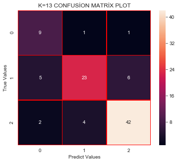

```python
#KNN CONFUSİON MATRİX PLOT
plt.figure(figsize=(6,5))
sns.heatmap(knn_cm_data3, annot = True, linewidth = 0.5, linecolor="red", fmt = ".0f")
plt.xlabel("Predict Values")
plt.ylabel("True Values")
plt.title("K=13 CONFUSİON MATRİX PLOT")
plt.show()
```

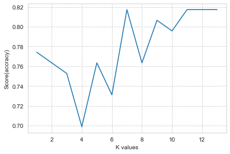

```
k : 13 and max Score: 0.8064516129032258
```

```python
#find avaible value of k
score_list_data3=[]
k_value_data3=[]
for i in myList_data3:
    knn_available_data3=KNeighborsClassifier(n_neighbors=i)
    knn_available_data3.fit(X_train,y_train.values.ravel())
    score_list_data3.append(knn_available_data3.score(X_test,y_test))
    k_value_data3.append(i)
plt.plot(myList_data3,score_list)
plt.xlabel("K values")
plt.ylabel("Score(accracy)")
plt.show()

#we will see when max accuracy with k value
print("k : {} and max Score: {}".format(i,np.max(score_list_data3)))
```